# Pilot-c report: a narrower near-optimal set, a matched correction, and the band’s calibration

A review document: the third pilot of the re-scoped proposal, its results, the draft spec, and the decisions log

Published

October 29, 2026

# Summary

**Scope.** This document reports the third pilot[^1] of the re-scoped proposal (`proposal.md`, sections 12 and 13, “Pool first or optimize first? Cutoffs from multiply imputed biomarker data”), run after the re-pilot’s close call to test five revisions: a near-optimal set built from comparisons between thresholds, an optimism correction whose resamples are imputed as often as the analysis, a better-calibrated band, a grid built from completed values, and a narrower design. It was built from `project-spec.md`, `decisions.md`, the pre-registration `preregistration.md`, and the saved results in `pilot-c/results/`; the re-pilot’s cell summaries and the first pilot’s NHANES description are read, read-only, from `pilot-b/results/` and `pilot/results/`. Every number in the text and figures is computed from those files when the document renders.

| Pilot question | Answer | Key evidence |
| --- | --- | --- |
| 1. Does the problem exist? | yes | optimism of the reported index 0.0261 (MCSE 0.0010); pointwise intervals cover the whole curve in 0.280 of replicates |
| 2. Large enough at realistic n? | yes | optimism 0.0261 at 40% and 0.0386 at 60% missing, against 0.01 |
| 3. Obvious fix? | nearly; a close call | corrected bias 0.0055 (MCSE 0.0011); comparison-based set holds the best threshold in 0.997 at 0.60 of the band-based length; band coverage 0.927 (bootstrap) and 0.923 (hybrid) against 0.93 to 0.97 |

# The idea

## In plain language

A clinic that picks a cutoff for a blood test from its own data reports how well the cutoff works, as sensitivity plus specificity minus one (the Youden index[^4]). That number is optimistic, because the cutoff was chosen where the data happened to favour it, and the study reports no margin of error, because no method gives one when missing test values were filled in by multiple imputation[^5]. The earlier pilots showed both problems at 250 patients per group and tested three repairs: a margin of error for the whole accuracy curve (a simultaneous band), the range of cutoffs that cannot be told apart from the best one (a near-optimal set), and a corrected index from a bootstrap[^6].

Two of the repairs fell short for reasons of construction. The range of cutoffs was so wide, about two-thirds of the thresholds considered, that it said little: it was built by asking whether a cutoff’s best case reaches the best cutoff’s worst case, which counts the uncertainty twice. This pilot builds it the other way, by asking for each pair of cutoffs whether one is clearly better than the other, for example “1.06 is better than 0.2, but not clearly better than 0.8”. The corrected index was too large where many values were missing, plausibly because each bootstrap copy was filled in twice while the analysis fills in twenty times; this pilot fills each copy in twenty times.

## Potential impact

No published method gives a band for the accuracy curve, a set of near-optimal thresholds, or an optimism-corrected index when the marker has been multiply imputed. Complete-data methods exist for intervals of the index and the cutoff (Bantis, Nakas, and Reiser 2019) and for the joint uncertainty of sensitivity and specificity at an estimated cutoff (Bantis, Nakas, and Reiser 2014). For imputed data, Long, Zhang, and Hsu (2011) pooled the curves and reported a threshold with no uncertainty, and the general results on combining the bootstrap with imputation (Bartlett and Hughes 2020; von Hippel and Bartlett 2021) have not been applied to a curve or its maximum. The cutoff itself is a cube-root estimator for which the standard bootstrap is inconsistent (Cattaneo, Jansson, and Nagasawa 2020).

The problem is a reporting gap. Studies that impute a missing marker and publish an optimal cutoff report an index that overstates the cutoff’s accuracy and no measure of how well the cutoff is determined, and many authors do not report the precision of their cutpoints even with complete data (Thiele and Hirschfeld 2023).

If the repairs work, an analyst reports the pooled curve with a calibrated band, a range of cutoffs as good as the best that is narrow enough to act on, and an index that estimates the accuracy the chosen cutoff will deliver, in place of one number. That changes how diagnostic-accuracy and prediction studies with imputed markers present a cutoff, in laboratory medicine and epidemiology in particular, where the cotinine application below sits. This pilot shows how far the repairs have come: the reported index overstates the chosen cutoff’s accuracy by 0.026 in the base cell and the 20-imputation correction leaves 0.006 of it (Figure 6); the near-optimal set is 40% shorter than the earlier construction without losing coverage (Figure 5); and the band is within a point or two of its nominal coverage (Figure 4).

## Application: the study behind the data

### The study

The National Health and Nutrition Examination Survey[^7] (NHANES) samples the noninstitutionalized United States population in two-year cycles, interviews each participant, and examines a subsample in a mobile examination center, where blood is drawn. Serum cotinine[^8], the main metabolite of nicotine, was measured in examined participants aged 3 and over in the cycles 2013-2014, 2015-2016, and 2017-2018, with the same laboratory method (isotope-dilution liquid chromatography with tandem mass spectrometry) and the same lower limit of detection, 0.015 ng/mL; values below it are set to the limit divided by the square root of two (documentation files `COT_H`, `COT_I`, and `COT_J`, read 2026-10-28). Adults answer a smoking questionnaire (`SMQ`). The files are public at wwwn.cdc.gov/Nchs/Data/Nhanes/Public/, with no login.

Two studies used these survey data to choose a cotinine cutoff for current smoking. Benowitz, Bernert, Caraballo, Holiday, and Wang (2009), *American Journal of Epidemiology* 169(2):236-48 (doi:10.1093/aje/kwn301), used the cycles 1999 to 2004 and found that optimal cutoffs differed by race/ethnicity, 5.92 ng/mL for non-Hispanic Black, 4.85 for non-Hispanic White, and 0.84 for Mexican American adults. Tompkins, Beltran, and Bedno (2019), *Biomarkers in Medicine* 13(12):1025-1033 (doi:10.2217/bmm-2019-0027), used the cycles 2009 to 2014 and found an adult cutoff of 3.63 ng/mL that differed by sex and race/ethnicity. In the three cycles used here, 17,948 adults answered the smoking question, 3,353 of them current smokers[^9], and cotinine is missing for 9.6% of them (Table 1).

Table 1: Adults aged 18 and over with an answer to the smoking question, by NHANES cycle: current smokers, nonsmokers, participants not examined, participants with serum cotinine missing (of whom some were examined), values below the limit of detection, and the share missing. Computed from the downloaded NHANES files by pilot/nhanes.R (../pilot/results/nhanes_summary.rds, read-only).

|  | Cycle | Adults | Smokers | Nonsmokers | Not examined | Cotinine missing | Missing, examined | Below detection | Share missing |
| --- | --- | --- | --- | --- | --- | --- | --- | --- | --- |
| 2013-2014 | 2013-2014 | 6,111 | 1,232 | 4,879 | 189 | 471 | 282 | 1,759 | 7.7% |
| 2015-2016 | 2015-2016 | 5,981 | 1,100 | 4,881 | 256 | 586 | 330 | 1,794 | 9.8% |
| 2017-2018 | 2017-2018 | 5,856 | 1,021 | 4,835 | 323 | 658 | 335 | 1,783 | 11.2% |
| 1 | All three | 17,948 | 3,353 | 14,595 | 768 | 1,715 | 947 | 5,336 | 9.6% |

### Why the Youden index

A cotinine cutoff classifies a participant as a smoker when the measured value exceeds it, and the Youden index of a cutoff, sensitivity plus specificity minus one, is the share of smokers called smokers minus the share of nonsmokers called smokers. Both cotinine studies chose the cutoff that maximizes it. The estimand is the maximizer of the population Youden curve and the curve’s maximum; the question here is how to estimate both, with their uncertainty, when some cotinine values are missing and imputed. The proposed analysis imposes missingness at random on the adults with observed cotinine, so that the full-data cutoff is the benchmark, imputes, and compares the two pooling orders, overall and by race/ethnicity.

### Did the original study compute it?

Partly. Both studies estimated the optimal cutoff from receiver operating characteristic curves on participants with observed cotinine, and Benowitz et al. estimated it within race/ethnicity groups. Neither study imputed the missing cotinine values, and neither reported the uncertainty of its cutoff in the passages read for this project. The question here is new: how the cutoff, its index, and their uncertainty should be pooled once missing values are imputed, and whether the stratum-specific cutoff or the cutoff that is optimal for the population as a whole is the target within each race/ethnicity group.

## In symbols

Each group’s marker distribution ($F_0$, $F_1$), the Youden curve ($J(c)$), its maximizer and maximum ($c^*$, $J^*$), the pooled curve of $L$ completed datasets ($\bar J$) on a grid of thresholds ($c_1, \dots, c_K$), its covariance ($\Sigma$), the chosen cutoff ($\hat c$), the reported index ($A$), a band with limits $\ell$ and $u$, the band-based set ($S_B$), and the comparison-based set ($S_C$) are related by

$$\begin{aligned}
J(c) &= F_0(c) - F_1(c), \qquad \hat c = \arg\max_c \bar J(c), \qquad A = \max_c \bar J(c) \\
\text{optimism} &= A - J(\hat c) \\
\text{band} &: \ \bar J(c_k) \pm q\,\sqrt{\Sigma_{kk}} \\
S_B &= \{c_k : u(c_k) \ge \max_j \ell(c_j)\} \\
S_C &= \{c_k : \bar J(c_j) - \bar J(c_k) \le q_D\,\mathrm{SE}_{jk} \ \text{for every } j \ne k\}, \qquad \mathrm{SE}_{jk}^2 = \Sigma_{jj} + \Sigma_{kk} - 2\Sigma_{jk}.
\end{aligned}$$

| Symbol | Meaning |
| --- | --- |
| $X$, $D$, $Z$ | the marker, the disease status (0 or 1), the auxiliary variable that predicts the marker |
| $J(c)$, $c^*$, $J^*$ | the Youden curve, its maximizer, its maximum |
| $\bar J$, $\hat c$, $A$ | the pooled curve of $L = 20$ completed datasets, its maximizer, its maximum |
| $c_1, \dots, c_K$ | 41 thresholds between the 10% and 90% quantiles of the completed values |
| $\Sigma$ | covariance of $\bar J$ on the grid, from bootstrap-then-impute with the imputation part rescaled to $L$ |
| $q$, $q_D$ | critical values of the band and of the comparisons |
| $S_B$, $S_C$ | the band-based and the comparison-based near-optimal sets |

The target of a set is the grid threshold with the largest true $J$. Both sets contain it when their critical values hold. For $S_C$: if every comparison of the best threshold $c_{k^*}$ with another is within its bound, then $\bar J(c_j) - \bar J(c_{k^*}) \le J(c_j) - J(c_{k^*}) + q_D\,\mathrm{SE}_{jk^*} \le q_D\,\mathrm{SE}_{jk^*}$. The difference between nearby thresholds varies much less than the curve, because their errors move together, so $\mathrm{SE}_{jk}$ is small where $c_j$ is near $c_k$ and $S_C$ is narrower than $S_B$. The two constructions compared differ only in their critical values: the bootstrap construction reads them from the resamples, the hybrid construction from the normal law with covariance $\Sigma$.

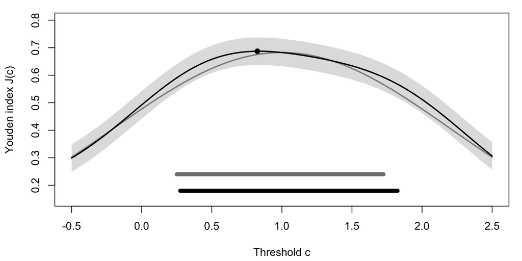

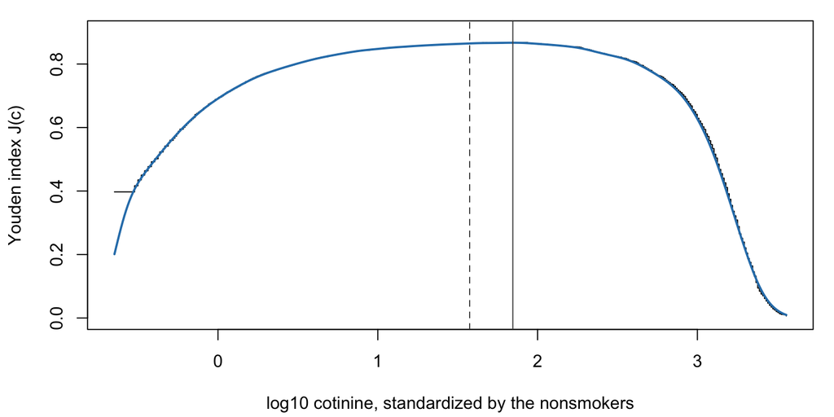

Figure 2: The real data: the full-data Youden curve of log serum cotinine among NHANES adults (2013 to 2018, participants with cotinine observed), current smokers against everyone else, on the scale used in the simulation (log cotinine standardized by the nonsmokers’ mean and standard deviation). Black: the empirical curve; blue: the Gaussian-kernel curve. The solid vertical line is the maximizer of the kernel curve; the dashed line is the adult cutoff of 3.63 ng/mL of Tompkins, Beltran, and Bedno (2019). From ../pilot/results/nhanes_summary.rds, read-only.

The full-data curve peaks at 7.35 ng/mL with an index of 0.868 (empirical curve); at the published adult cutoff of 3.63 ng/mL the empirical index is 0.865, lower by 0.003 for a cutoff half as large. The curve is flat over that range, which is the situation in which a near-optimal set is wide and a single cutoff says little. On the standardized scale its curvature at the peak is 0.229, between the flat (0.220) and the sharp (0.484) shapes of the earlier pilots of the simulation, and its maximum, 0.867, is above both. The cutoff here is higher than the published ones; the definitions differ, since everyone who is not a current cigarette smoker, including users of other tobacco products, counts as a nonsmoker here.

## Critiquing the model

Any model is a simplification, and the useful question is not whether it is true but where it bends and whether the bend matters for the question being asked. The model above was chosen so that the problem could be written as a formula and checked by simulation, and each simplification that made that possible is a place where real data may behave differently. The table lists the main ones. Work through it one row at a time. The first column names the feature and the symbols in the equations that carry it, so find them there first. Then decide in your own words how the feature could fail for real data before reading the second column, and finally read the third column for what should be done to check it. Several of these checks are natural first tasks for the project. Which of them the pilot examined, and which it left open, is for you to find when you read the Methods and Results that follow.

| Feature of the model | Why it may not be realistic | What should be done to check it |
| --- | --- | --- |
| Binormal marker with a sharp symmetric peak | Real markers are skewed or have a point mass (cotinine below the limit of detection), and a flat peak, as in the cotinine data, widens every near-optimal set | Simulate from the real cotinine distribution; restore the flat shape in the full design |
| The unknown parameters: $\delta$, $\sigma_1$, the auxiliary strength, the missingness coefficients | One shape and one auxiliary strength were chosen; the band’s width, the sets’ length, and the optimism depend on all of them | Estimate them from the NHANES cohort and place the real data on each gradient |
| One auxiliary and a correctly specified normal imputation model | Real imputation models carry several covariates and are misspecified; the normal engine is correct here only because $X$ and $Z$ are jointly normal within groups | Add an arm with several auxiliaries and one omitted from the imputation model |
| Missing at random, concentrated at high $Z$ | Missingness tied to the marker’s own value is not corrected by either engine | State the assumption; compare participants with and without cotinine on observed covariates |
| The covariance $\Sigma$ from bootstrap-then-impute, rescaled from 2 to 20 imputations | The rescaling assumes the imputation part of the variance falls as $1/L$; with few resamples the estimated $\Sigma$ is noisy, and its eigenvalues were clipped at zero | Vary the resamples and the imputations per resample; compare $\Sigma$ with the Monte Carlo covariance of $\bar J$ |
| The normal law of the hybrid construction | The sup-t and comparison critical values assume $\bar J$ is jointly normal on the grid; the empirical curve is a step function and its differences between nearby thresholds are counts of few subjects | Compare the hybrid and bootstrap constructions across sizes, down to 100 per group |
| The comparison-based set’s guarantee at the grid’s best threshold | The guarantee is for the best grid point, not for $c^*$; a coarse grid or a flat peak makes the two differ | Report the set’s coverage of $c^*$ by interpolation as well; vary the grid |
| The bootstrap optimism correction for a cube-root estimator | The standard bootstrap does not reproduce a cube-root estimator’s distribution (Cattaneo, Jansson, and Nagasawa 2020), so the resamples’ optimism need not match the original’s | Compare the correction across sizes; try a subsampling version |

# Methods

## Design

The pilot simulates the earlier pilots’ binormal marker with the sharp peak, missing at random through one auxiliary, at 250 per group, and applies the empirical estimator to 20 completed datasets. Every replicate builds the pointwise, Rubin’s-rules, bootstrap, and hybrid bands on a 41-point grid from the completed values; the band-based and comparison-based sets of the bootstrap and hybrid constructions; and the optimism correction with 20 and with 2 imputations per resample. The 5 cells are no missing values, and 40% and 60% missing imputed by predictive mean matching[^10] or by Bayesian normal linear regression[^11], for 1,300 replicates per cell, run in seeded blocks of 100 on 7 workers. The known-answer checks run the same code on cases with known answers.

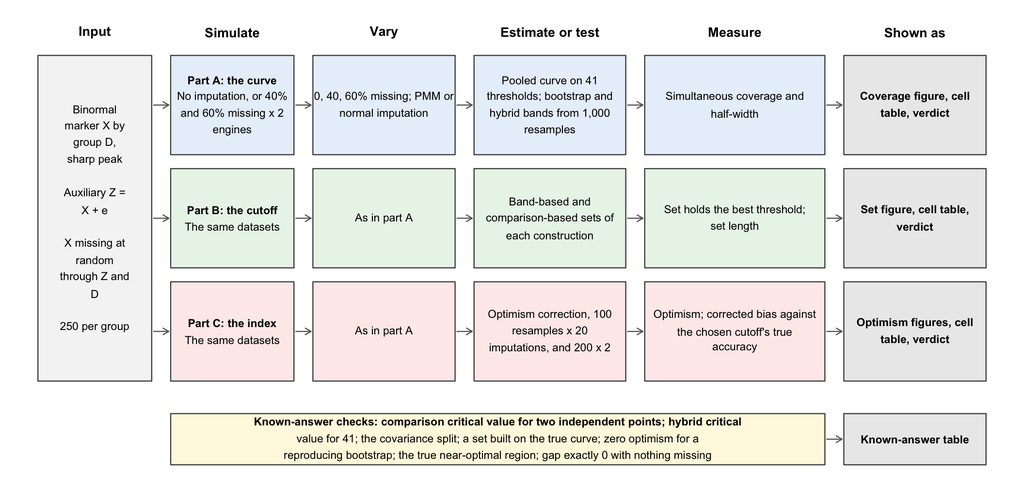

Figure 3: The design at a glance. Each row is one part of the pilot, read from left to right; all parts use the same simulated datasets. The bands’ coverage is in Figure 4, the sets’ coverage and length in Figure 5, the optimism and its corrections in Figure 6 and Figure 7, every cell in Table 4, and the verdict in Table 3; the checks are in Table 2.

Each figure and table in the Results traces back to one row of this diagram, and the row says what its points or entries represent.

| Part | What is simulated | Main factors | Replicates |
| --- | --- | --- | --- |
| A | $X \mid D{=}0 \sim N(0,1)$, $X \mid D{=}1 \sim N(2, 1)$; $Z = X + e$; $X$ missing with probability $\mathrm{expit}(\alpha_0 + Z + 0.5D)$; 20 imputations; 1,000 resamples within groups, each imputed tw… | missing fraction, engine | 1,300 per cell, 5 cells |
| B | the same resamples | as part A | the same |
| C | 100 further resamples, each imputed 20 times; the first 200 of part A’s resamples | as part A | the same |

The base cell has 40% missing imputed by predictive mean matching; its normal twin uses normal imputation; the null cell has nothing missing. The covariance of the pooled curve comes from part A’s resamples, with the imputation part estimated from the two imputations of each resample and rescaled to 20. The bootstrap construction reads its critical values from the resamples; the hybrid construction from 5,000 draws of the normal law with that covariance. The true optimal cutoff is $c^* = 1.000$ and $J^* = 0.6827$; the true thresholds within 0.01 of $J^*$ span 0.41 units.

## Known-answer checks

Known-answer checks come before any result, because every later number is only as good as the simulation that produced it. Each check sets up a case where the correct answer is known from theory, runs the simulation code on it, and compares the two. Agreement says nothing about the scientific question or about real data. It says that the code does what the model says. Disagreement means stopping to look for a bug before reading anything else, and the same checks apply to any code you write for the project.

Read each row of the table in four steps: the setting that was simulated, the known answer for that setting, what the simulation gave, and whether the gap between the two is small compared with the Monte Carlo standard error (MCSE). The MCSE is how much a simulated result moves from run to run because only a finite number of replicates was used. A gap within about two MCSE is noise, and a gap of several MCSE is a problem.

Table 2: Known-answer checks, from results/known_answers.rds (written by pilot.R before the run, the same checks the test suite asserts) and, for the last row, from results/cell_summaries.rds (the null cell, where nothing is imputed).

| Check | Setting | Known answer | Simulation gave | How to read it |
| --- | --- | --- | --- | --- |
| Comparison critical value | two independent coordinates, 200,000 draws | qnorm(0.95) | 1.64495 | 9.859e-05 from the known value, against a tolerance of 0.02, so the check passes. |
| Hybrid band critical value | 41 independent coordinates, 100,000 draws | qnorm((1 + 0.95^(1/41)) / 2) | 3.23046 | 0.003303 from the known value, against a tolerance of 0.02, so the check passes. |
| Covariance split, diagonal | synthetic resamples, M = 2, L = 20 | 4e-4 + 9e-4 / 20 | 0.000460251 | 1.525e-05 from the known value, against a tolerance of 2e-05, so the check passes. |
| Covariance split, off-diagonal | synthetic resamples, M = 2, L = 20 | 2e-4 - 3e-4 / 20 | 0.000181385 | 3.615e-06 from the known value, against a tolerance of 2e-05, so the check passes. |
| Comparison-based set | built on the true curve | contains the best grid point | 1 | 0 from the known value, against a tolerance of 0, so the check passes. |
| Optimism of a reproducing bootstrap | 20 identical completed datasets per resample | exactly 0 | 0 | 0 from the known value, against a tolerance of 0, so the check passes. |
| True near-optimal region | sharp shape, within 0.01 of J* | twice the symmetric half-width | 0.407994 | 1.238e-14 from the known value, against a tolerance of 1e-08, so the check passes. |
| Pooling-order gap with nothing missing | the null cell | exactly 0 in every replicate | 0 nonzero of 1,300 | No replicate has a nonzero gap, so the check passes. |

Every row is an exact identity or an approximation judged against a tolerance. The bands’ coverage in the null cell is not a known-answer check, because the 95% level holds only approximately at 250 per group; it is part of the pass rule and reported with the results.

# Results

## How to read the outputs

Each output traces back to a row of the design diagram (the captions name the part where one applies). Read each in the same four steps. First, find its row in the diagram, which says what was simulated and what was varied. Second, work out what one point or one table entry is, usually one combination of the varied factors, averaged over replicates. Third, identify the reference value that would hold if nothing were wrong, shown as a dashed or grey line wherever possible. Fourth, look for where the results leave that reference, and for which settings they do. The outputs report three kinds of quantity.

- **Bias** is the average of an estimate minus its true value. When the truth is no difference, any average difference from 0 is a spurious difference created by the problem under study.
- **Level** is how often a test rejects when there is truly nothing to find. A correct test at 0.05 rejects 5% of the time, so a rate above 0.05 means too many false alarms.
- **Power** is how often a test rejects when there is a real effect. More is better, but only when the level is not inflated, because a test that rejects too often also looks powerful.

All rates and averages come from simulation, so each carries Monte Carlo error. That is why the figures show bars or a grey band, and why small differences should not be over-read.

This pilot has no test, so level and power do not arise; it reports four further quantities. A band’s simultaneous coverage is the share of replicates in which it contains the true curve at all 41 thresholds at once, 95% for a correct band; the pointwise intervals read as a band cover less often, because each of 41 intervals has its own 5% chance to miss. A set’s coverage is the share of replicates in which it contains the grid threshold with the largest true $J$, and its length is the range of thresholds it spans. The optimism is the reported index minus the true accuracy of the cutoff it picked, averaged over replicates; a corrected index’s bias is the same difference after the correction.

## The bands

**Figure guide (part A, every cell).** A correct band covers the true curve in 95% of replicates, the solid line; the dashed lines are the pre-registered limits 0.93 and 0.97. One point is one cell’s coverage over 1,300 replicates, with plus and minus two MCSE for the two candidate bands: bootstrap (black circles), hybrid (blue triangles), Rubin’s rules (open squares), and the pointwise intervals (orange crosses). Look for: whether either candidate sits inside the limits in the null cell, the base cell, and the normal twin; how far the Rubin’s-rules band moves with predictive mean matching.

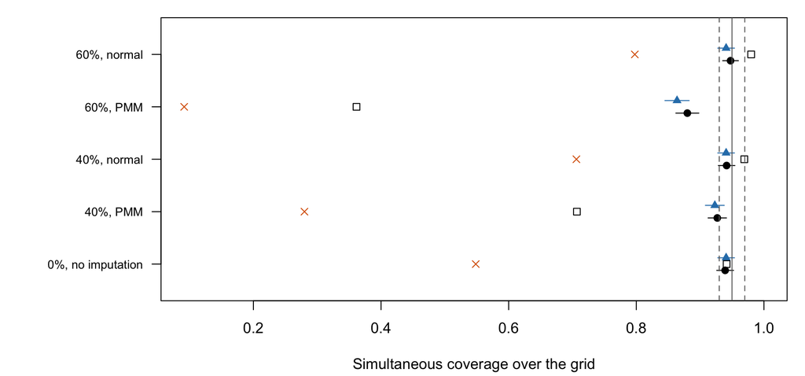

Figure 4: Part A: simultaneous coverage over the 41-threshold grid in every cell: bootstrap band (black, plus and minus two MCSE), hybrid band (blue, plus and minus two MCSE), Rubin’s-rules band (open squares), pointwise intervals read as a band (orange). Solid line 0.95; dashed lines 0.93 and 0.97. From results/cell_summaries.rds.

## The near-optimal sets

**Figure guide (part B, every cell).** Left: the share of replicates in which a set contains the best grid threshold, with the 0.93 threshold dashed; right: the sets’ mean length, with the true range of thresholds within 0.01 of $J^*$ dotted. One point is one cell: comparison-based sets (filled) and band-based sets (open), bootstrap (black) and hybrid (blue). Look for: whether the comparison-based sets keep their coverage while their length falls; how far both sets stay from the true range.

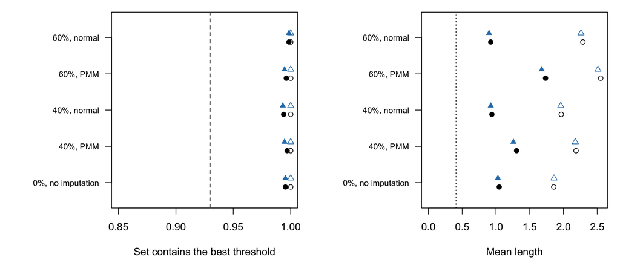

Figure 5: Part B: the near-optimal sets in every cell. Left: share of replicates in which the set contains the best grid threshold (comparison-based filled, band-based open; bootstrap black, hybrid blue), 0.93 dashed. Right: mean length, with the length of the true range of thresholds within 0.01 of J* dotted. From results/cell_summaries.rds.

## The optimism and its correction

**Figure guide (part C, every cell).** An unbiased index sits on the zero line. One row is one cell: the mean optimism of the reported index (open circles), the bias of the 20-imputation corrected index (filled black), and of the 2-imputation one (grey triangles), all against the true accuracy of the chosen cutoff, with plus and minus two MCSE for the first two. Look for: whether the 20-imputation correction stays near zero as the missing fraction grows, where the 2-imputation one moves away.

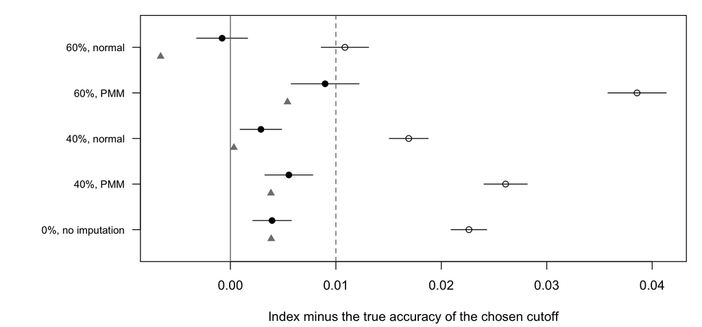

Figure 6: Part C: mean optimism of the reported index (open), bias of the 20-imputation corrected index (filled, plus and minus two MCSE), and bias of the 2-imputation corrected index (grey triangles), all against the true accuracy of the chosen cutoff, in every cell. Solid line 0; dashed line 0.01. From results/cell_summaries.rds.

**Figure guide (base cell and its normal twin, replicate by replicate).** If the correction measured each study’s own optimism, the points would rise along the dashed identity line. One point is one replicate: its optimism against the 20-imputation correction. Look for: whether the points rise with the optimism or form a flat band; where most of them sit.

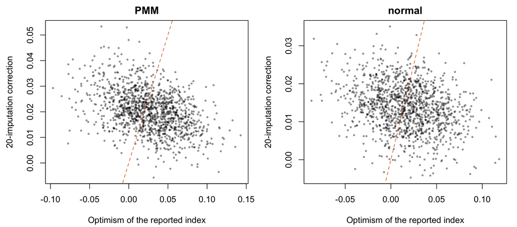

Figure 7: Base cell (40% missing, predictive mean matching, left) and its normal twin (right), all 1300 replicates each: the reported index’s optimism against the 20-imputation correction, identity line dashed. From results/base_cell_points.rds.

## Numbered findings

Each finding is a claim followed by the output behind it. Read the claim, open the output, and check that you can see the claim there before accepting it. A claim that cannot be seen in the output is a question to raise with the user.

1. **The problem reproduces.** The optimism of the reported index is 0.0261 (MCSE 0.0010) in the base cell, 0.0226 (MCSE 0.0008) with nothing missing, and 0.0386 at 60% missing with predictive mean matching; the pointwise intervals cover the whole curve in 0.09 to 0.80 of replicates across cells (Figure 6; Figure 4).
2. **The comparison-based set keeps its coverage and is about half as long.** It contains the best grid threshold in 0.993 to 0.998 of replicates in every cell, and its length is 0.40 to 0.68 of the band-based set’s (Figure 5; Table 4).
3. **The set is still wider than the true range of good thresholds.** Its mean length runs from 0.90 to 1.73, against 0.41 for the thresholds whose true index is within 0.01 of $J^*$; its coverage, above 0.99, says the critical value is conservative (Figure 5).
4. **The 20-imputation correction removes most of the optimism and no longer overshoots with normal imputation.** Its bias is 0.0055 (MCSE 0.0011) in the base cell and 0.0029 (MCSE 0.0010) in the normal twin. At 60% with normal imputation it is -0.0008 (MCSE 0.0012), where the 2-imputation correction overshoots to -0.0066; with predictive mean matching at 60% both corrections fall short, 0.0090 and 0.0054 (Figure 6; Table 4).
5. **The correction does not track a study’s own optimism.** Across replicates the correlation between the optimism and the 20-imputation correction is -0.40 in the base cell and -0.27 in the normal twin (Figure 7).
6. **The grid from the completed values holds the optimal cutoff.** The grid contains $c^*$ in every replicate of every cell, where the re-pilot’s grid from observed values missed the flat shape’s $c^*$ at both missing fractions (Table 4; the re-pilot’s report).
7. **The bootstrap and hybrid bands cover slightly below 95% in every cell.** Their coverage runs from 0.864 to 0.948: inside the 0.93 to 0.97 limits without imputation and with normal imputation, just below at 40% with predictive mean matching, and 0.880 and 0.864 at 60% with it. The base cell’s bootstrap coverage was 0.910 in the re-pilot with 200 resamples (Figure 4; Table 3).
8. **The two constructions nearly agree, so the shortfall is mostly in the covariance they share.** Their mean critical values are 2.95 and 2.94 in the base cell and -0.01 to 0.08 apart across cells. Their coverage differs by at most 0.016, the largest difference at 60% with predictive mean matching, where the hybrid band is the lower (Table 4).
9. **Rubin’s rules undercover with predictive mean matching.** The Rubin’s-rules band covers 0.969 to 0.980 with normal imputation and 0.362 to 0.707 with predictive mean matching, against 0.942 without imputation. Rubin’s rules take the between-imputation spread at face value, so this fits predictive mean matching’s imputations varying less between datasets than the uncertainty they carry, or being biased where donors are sparse, as the first pilot’s cutoffs were at 60% missing; the pilot does not separate the two (Figure 4).
10. **One cell differs from the re-pilot.** The 60% predictive-mean-matching cell’s optimism is 0.0386 (MCSE 0.0014) here and was 0.0301 (MCSE 0.0022) in the re-pilot, 3.2 combined MCSE apart; the other cells agree (decisions log, D5).

## Tables

**Table guide (the verdict).** One row is one criterion of the pre-registered pass rule: the cell, the measure, its estimate with its MCSE, the threshold, whether it is met, and whether it lies within three MCSE of the threshold (near). Clause (b) has a block of rows for each construction; question 3 needs (a) and one whole block. Which construction, if either, meets every row of its block?

Table 3: Pilot-c’s pass rule applied (pilot-c/verdict.R, results/verdict.rds): every criterion of the pre-registration, its estimate and MCSE, its threshold, and whether it is met or near (within three MCSE of the threshold).

| Question | Clause | Cell | Measure | Estimate | MCSE | Threshold | Met | Near |
| --- | --- | --- | --- | --- | --- | --- | --- | --- |
| Q1 | a | base (40%, PMM) | optimism of the apparent index | 0.0261 | 0.0010 | > 3 MCSE | yes |  |
| Q1 | b | base (40%, PMM) | simultaneous coverage of pointwise intervals | 0.2800 | 0.0125 | < 0.90 | yes |  |
| Q2 | a | base (40%, PMM) | optimism of the apparent index | 0.0261 | 0.0010 | >= 0.01 | yes |  |
| Q2 | a | 60% (PMM) | optimism of the apparent index | 0.0386 | 0.0014 | >= 0.01 | yes |  |
| Q3 | a | base (40%, PMM) | \|corrected bias, 20 imputations\| / optimism | 0.2124 | 0.0354 | <= 0.5 | yes |  |
| Q3 | a | normal twin (40%, normal) | \|corrected bias, 20 imputations\| / optimism | 0.1710 | 0.0490 | <= 0.5 | yes |  |
| Q3 | b, boot | null (no missing values) | simultaneous coverage of the band | 0.9392 | 0.0066 | in [0.93, 0.97] | yes | near |
| Q3 | b, boot | base (40%, PMM) | simultaneous coverage of the band | 0.9269 | 0.0072 | in [0.93, 0.97] | no | near |
| Q3 | b, boot | normal twin (40%, normal) | simultaneous coverage of the band | 0.9415 | 0.0065 | in [0.93, 0.97] | yes | near |
| Q3 | b, boot | base (40%, PMM) | comparison-based set contains the best threshold | 0.9969 | 0.0015 | >= 0.93 | yes |  |
| Q3 | b, boot | base (40%, PMM) | set length / band-based set length | 0.5973 | 0.0025 | <= 0.75 | yes |  |
| Q3 | b, boot | normal twin (40%, normal) | comparison-based set contains the best threshold | 0.9938 | 0.0022 | >= 0.93 | yes |  |
| Q3 | b, boot | normal twin (40%, normal) | set length / band-based set length | 0.4775 | 0.0022 | <= 0.75 | yes |  |
| Q3 | b, hybrid | null (no missing values) | simultaneous coverage of the band | 0.9408 | 0.0065 | in [0.93, 0.97] | yes | near |
| Q3 | b, hybrid | base (40%, PMM) | simultaneous coverage of the band | 0.9231 | 0.0074 | in [0.93, 0.97] | no | near |
| Q3 | b, hybrid | normal twin (40%, normal) | simultaneous coverage of the band | 0.9408 | 0.0065 | in [0.93, 0.97] | yes | near |
| Q3 | b, hybrid | base (40%, PMM) | comparison-based set contains the best threshold | 0.9946 | 0.0020 | >= 0.93 | yes |  |
| Q3 | b, hybrid | base (40%, PMM) | set length / band-based set length | 0.5785 | 0.0026 | <= 0.75 | yes |  |
| Q3 | b, hybrid | normal twin (40%, normal) | comparison-based set contains the best threshold | 0.9931 | 0.0023 | >= 0.93 | yes |  |
| Q3 | b, hybrid | normal twin (40%, normal) | set length / band-based set length | 0.4708 | 0.0022 | <= 0.75 | yes |  |

**Table guide (every cell).** One row is one cell. The first block is the index: the optimism and the two corrected indices’ bias, all against the true accuracy of the chosen cutoff. The second is the curve: the coverage of the four bands. The third is the cutoff: the coverage and mean length of the comparison-based sets, and the ratio of their length to the band-based sets’. The last two columns are the pooling-order note. Where does the 2-imputation correction drift from the 20-imputation one, and where is the hybrid band wider or narrower than the bootstrap band?

Table 4: Every cell of pilot-c: optimism of the reported index and bias of the 20- and 2-imputation corrected indices (MCSE); simultaneous coverage (MCSE) of the pointwise, Rubin’s-rules, bootstrap, and hybrid bands; coverage of the best threshold, mean length, and length ratio to the band-based set of the bootstrap and hybrid comparison-based sets; the pooling-order gap and the cutoff’s RMSE ratio, optimize first over pool first. From results/cell_summaries.rds.

| Cell | Optimism | Corrected, 20 | Corrected, 2 | Pointwise | Rubin | Bootstrap | Hybrid | Set, bootstrap | Set, hybrid | Gap | RMSE ratio |
| --- | --- | --- | --- | --- | --- | --- | --- | --- | --- | --- | --- |
| 0%, no imputation | 0.0226 (MCSE 0.0008) | 0.0039 (MCSE 0.0009) | 0.0039 (MCSE 0.0009) | 0.548 | 0.942 (MCSE 0.007) | 0.939 (MCSE 0.007) | 0.941 (MCSE 0.007) | 0.995; 1.05; 0.56 | 0.995; 1.03; 0.55 | 0.0000 | 1.00 |
| 40%, PMM | 0.0261 (MCSE 0.0010) | 0.0055 (MCSE 0.0011) | 0.0038 (MCSE 0.0011) | 0.280 | 0.707 (MCSE 0.013) | 0.927 (MCSE 0.007) | 0.923 (MCSE 0.007) | 0.997; 1.31; 0.60 | 0.995; 1.26; 0.58 | 0.0027 | 0.80 |
| 40%, normal | 0.0169 (MCSE 0.0009) | 0.0029 (MCSE 0.0010) | 0.0003 (MCSE 0.0010) | 0.706 | 0.969 (MCSE 0.005) | 0.942 (MCSE 0.007) | 0.941 (MCSE 0.007) | 0.994; 0.94; 0.48 | 0.993; 0.92; 0.47 | 0.0042 | 0.78 |
| 60%, PMM | 0.0386 (MCSE 0.0014) | 0.0090 (MCSE 0.0016) | 0.0054 (MCSE 0.0016) | 0.092 | 0.362 (MCSE 0.013) | 0.880 (MCSE 0.009) | 0.864 (MCSE 0.010) | 0.996; 1.73; 0.68 | 0.995; 1.68; 0.67 | 0.0044 | 0.85 |
| 60%, normal | 0.0109 (MCSE 0.0011) | -0.0008 (MCSE 0.0012) | -0.0066 (MCSE 0.0012) | 0.798 | 0.980 (MCSE 0.004) | 0.948 (MCSE 0.006) | 0.941 (MCSE 0.007) | 0.998; 0.92; 0.40 | 0.998; 0.90; 0.40 | 0.0089 | 0.77 |

**Table guide (the numbers in the spec).** One row is one number that section 3 of the spec quotes, recomputed here from the result files. Does every number in the spec match its row?

Table 5: Every number quoted in section 3 of project-spec.md, recomputed from results/verdict.rds.

| Item | Cell | Measure | Value | MCSE |
| --- | --- | --- | --- | --- |
| Q1a | base (40%, PMM) | optimism of the apparent index | 0.0261 | 0.00102 |
| Q1b | base (40%, PMM) | simultaneous coverage of pointwise intervals | 0.2800 | 0.01245 |
| Q2a | base (40%, PMM) | optimism of the apparent index | 0.0261 | 0.00102 |
| Q2a | 60% (PMM) | optimism of the apparent index | 0.0386 | 0.00138 |
| Q3a | base (40%, PMM) | \|corrected bias, 20 imputations\| / optimism | 0.2124 | 0.03535 |
| Q3a | normal twin (40%, normal) | \|corrected bias, 20 imputations\| / optimism | 0.1710 | 0.04899 |
| Q3b, boot | null (no missing values) | simultaneous coverage of the band | 0.9392 | 0.00663 |
| Q3b, boot | base (40%, PMM) | simultaneous coverage of the band | 0.9269 | 0.00722 |
| Q3b, boot | normal twin (40%, normal) | simultaneous coverage of the band | 0.9415 | 0.00651 |
| Q3b, boot | base (40%, PMM) | comparison-based set contains the best threshold | 0.9969 | 0.00154 |
| Q3b, boot | base (40%, PMM) | set length / band-based set length | 0.5973 | 0.00245 |
| Q3b, boot | normal twin (40%, normal) | comparison-based set contains the best threshold | 0.9938 | 0.00217 |
| Q3b, boot | normal twin (40%, normal) | set length / band-based set length | 0.4775 | 0.00216 |
| Q3b, hybrid | null (no missing values) | simultaneous coverage of the band | 0.9408 | 0.00655 |
| Q3b, hybrid | base (40%, PMM) | simultaneous coverage of the band | 0.9231 | 0.00739 |
| Q3b, hybrid | normal twin (40%, normal) | simultaneous coverage of the band | 0.9408 | 0.00655 |
| Q3b, hybrid | base (40%, PMM) | comparison-based set contains the best threshold | 0.9946 | 0.00203 |
| Q3b, hybrid | base (40%, PMM) | set length / band-based set length | 0.5785 | 0.00260 |
| Q3b, hybrid | normal twin (40%, normal) | comparison-based set contains the best threshold | 0.9931 | 0.00230 |
| Q3b, hybrid | normal twin (40%, normal) | set length / band-based set length | 0.4708 | 0.00217 |

# The draft spec

This is `project-spec.md`, read from the file when the document renders. It is the spec of the re-scoped proposal, a conditional draft[^12]. Anything the agent[^13] left for the user to decide is highlighted in yellow and starts with “To confirm”.

| Proposal | `proposal.md`, final 2026-10-28, re-scoped 2026-10-29 (section 12), revised for pilot-c 2026-10-29 (section 13) |
| --- | --- |
| Authors | as in `DESCRIPTION` |
| Written | 2026-10-28; rewritten for the re-scope 2026-10-29; section 3 for pilot-c 2026-10-29 |
| Status | draft 2026-10-28 |

## 1. Question and why it matters

**Question (one sentence):** When a biomarker is missing at random and multiply imputed, do a simultaneous band for the pooled Youden curve, the set of thresholds the band cannot separate from the best one, and a bootstrap-then-impute correction of the reported index give the curve’s uncertainty at the nominal rate and an index that does not overstate the accuracy of the chosen cutoff?

**Why it matters:** An analyst who imputes a missing marker and reports an optimal cutoff reports an index that overstates the cutoff’s accuracy, by about two points of the Youden index at 250 per group in the first pilot, and no interval for the curve or the cutoff, because no method for either exists under imputation. If the procedure works, the analyst reports the pooled curve with its band, the near-optimal thresholds, and a corrected index; the order of pooling, which the first pilot showed changes the index by less than half a point, becomes a closed-form note.

## 2. Mechanism we suspect

The reported index is the maximum of a noisy curve, so it sits above the true accuracy of the threshold it picks: the maximum rewards the threshold where sampling noise happened to push the curve up. With $J(c) = F_0(c) - F_1(c)$, the pooled curve $\bar J$ of $L$ completed datasets, its maximizer $\hat c$, and its maximum $\max_c \bar J(c)$, the optimism is $\max_c \bar J(c) - J(\hat c) \ge 0$ in expectation; it is present without any missing data (Fluss, Faraggi, and Reiser 2005 report the empirical method’s poor performance) and imputation adds the pooling-order gap $\kappa \hat B_c / 2$ on top of it for an analyst who optimizes first. A bootstrap that repeats the whole analysis, imputation included, estimates that optimism if the resample’s maximum relates to the original curve as the original maximum relates to $J$; for a cube-root estimator the standard bootstrap is inconsistent (Cattaneo, Jansson, and Nagasawa 2020), so the correction may remove only part of it. For the curve itself, $\bar J(c)$ at a fixed $c$ is an average of differences of proportions, regular, so a band built from Rubin’s rules (the binomial covariance of the empirical curve within imputations plus the covariance of the curves between imputations) or from bootstrap-then-impute should cover $J$ over a range of thresholds at the nominal rate when the imputations are proper and unbiased. When the imputations are biased, as predictive mean matching was where donors are sparse in the first pilot, no variance method restores coverage, which is why the correctly specified normal imputation is in the design. A near-optimal set built from a band, $\{c : U(c) \ge \max_{c'} L(c')\}$, contains $c^*$ when the band covers, but it counts the band’s uncertainty twice and is wide (two-thirds of the grid in the re-pilot). The proposal’s own definition compares thresholds with each other: a threshold stays in the set unless another is better by more than the uncertainty of their difference, and the difference between nearby thresholds varies much less than the curve, so that set should be narrower with the same guarantee. The bootstrap correction of the index should repeat the analysis as it was done, with as many imputations per resample as the original, because averaging 20 imputations smooths the curve and lowers its optimism (the re-pilot’s normal-imputation cells).

## 3. Pilot

Filled twice: the plan when the spec is written, the answers after the verdict (stage 2, step 5). The first pilot (`pilot/`, `piloted-fail`) and the re-pilot (`pilot-b/`, `piloted-close-call`) are reported in their own folders; this section is pilot-c’s, after the revision of `proposal.md`, section 13.

**Code:** `pilot-c/pilot.R`, run from the project root with `Rscript pilot-c/pilot.R`; it calls the functions in `R/` (those of the earlier pilots, plus the grid from completed values, the covariance split, the hybrid band, and the comparison-based set). `pilot-c/verdict.R` applies the pass rule to the saved summaries.

**Pass rule:** from `proposal.md`, section 13, made exact in `pilot-c/preregistration.md`. The base cell is the sharp peak, 40% missing, 250 per group, predictive mean matching; its normal twin uses normal imputation; the null cell has nothing missing.

1. The problem exists if, in the base cell, the apparent index exceeds the true accuracy of the chosen cutoff by more than three Monte Carlo standard errors, and the pointwise Rubin’s intervals read as a band cover the curve in less than 0.90 of replicates.
2. It is large enough if the apparent index’s optimism is at least 0.01 in the base cell or in its 60% twin.
3. There is a fix if (a) the 20-imputation corrected index’s absolute bias against the true accuracy of the chosen cutoff is at most half the apparent index’s optimism in the base cell and in the normal twin; and (b) for the bootstrap or the hybrid construction, the band covers the curve over the grid in 0.93 to 0.97 of replicates in the null cell, the base cell, and the normal twin, and the comparison-based set contains the grid’s best threshold in at least 0.93 of replicates in the base cell and the normal twin, with a mean length at most 0.75 of the band-based set’s.

**Verdict file:** `pilot-c/results/verdict.rds` (with `pilot-c/results/verdict.csv`), written by `pilot-c/verdict.R` after the run.

**Plot:** `pilot-c/results/coverage-by-cell.png`, the coverage of each band and set in every cell, written by `pilot-c/verdict.R`.

**The three pilot answers:** status `piloted-close-call`, by the pre-registered rule, from `pilot-c/results/verdict.rds`; 1,300 replicates per cell (the pre-registered 2,000 lowered by the time box), run label `pilot`.

1. Does the effect exist? Yes. In the base cell the reported index exceeds the true accuracy of the chosen cutoff by 0.0261 (MCSE 0.0010), and the pointwise Rubin’s intervals read as a band contain the true curve at all 41 thresholds in 0.280 (MCSE 0.012) of replicates.
2. Is it large enough to matter at realistic sample sizes? Yes: the optimism is 0.0261 in the base cell and 0.0386 (MCSE 0.0014) with 60% missing, above 0.01.
3. Is there an obvious fix or diagnostic? Nearly. The 20-imputation correction leaves 0.21 (MCSE 0.04) of the optimism in the base cell and 0.17 (MCSE 0.05) in the normal twin. The comparison-based sets contain the best threshold in 0.997 and 0.995 of the base cell’s replicates, at 0.60 and 0.58 of the band-based sets’ length. The bands cover in 0.939 (bootstrap) and 0.941 (hybrid) of replicates without imputation and in 0.942 and 0.941 with normal imputation, but in 0.927 (MCSE 0.007) and 0.923 (MCSE 0.007) in the base cell, below and near the 0.93 limit.

## 4. ADEMP skeleton

This becomes `protocol.md` at the design stop of stage 3.

**Aims.**

1. Do the Rubin’s-rules and the bootstrap-then-impute bands cover the Youden curve over a range of thresholds at 95%, and does the near-optimal set derived from each contain the optimal cutoff at least as often, across shapes, sizes, missing fractions, and imputation engines?
2. Does the bootstrap-then-impute optimism correction remove the overstatement of the reported index, against the true accuracy of the chosen cutoff and against the maximum of the curve?
3. As a closed-form note: how large is the pooling-order gap against $\kappa B_c / 2$, and is the averaged cutoff more accurate than the pooled argmax? For a discrete covariate (Aim 3 of the proposal), do the procedures recover the stratum-specific and the population-optimal cutoffs?

**Data-generating mechanisms.**

- Factors varied, with levels: the peak shape (sharp symmetric, flat asymmetric, two near-equal maxima); the missing fraction (0%, 20%, 40%, 60%); the sample size per group (100, 250, 1,000); the strength of the auxiliary; the imputation engine (predictive mean matching, normal linear regression, the nearest-neighbour method of Long, Zhang, and Hsu 2011 with several auxiliaries); the within-dataset estimator (empirical, Gaussian kernel); the number of bootstrap resamples and imputations per resample; for Aim 3, two to four strata with the prevalence ratio varied.
- Factors fixed, and why: missingness at random through the auxiliary and the disease status, because the claims are made under that assumption; the disease status always observed (verification bias is a different paper); equal group sizes in the base design, with one unbalanced arm at fixed total size.
- A cell where the answer is known: 0% missing, where the bands are complete-data bands and the pooling-order gap is exactly zero; a noiseless curve, whose optimism is zero; independent grid points, where the sup-t critical value has a closed form.

**Estimands.** The Youden curve $J(c)$ over a range of thresholds; its maximizer $c^*$ and maximum $J^*$; the true accuracy $J(\hat c)$ of a chosen threshold and the regret $J^* - J(\hat c)$; for Aim 3, $c_{\mathrm{cs}}(v)$ and $c_{\mathrm{pop}}(v)$.

**Methods compared.** For the curve: pointwise Rubin’s intervals (the default), the Rubin’s-rules sup-t band, the bootstrap-then-impute sup-t band, the hybrid band (bootstrap-then-impute covariance, normal-law critical value), and impute-then-bootstrap; for the cutoff, the comparison-based near-optimal set from each covariance, with the band-based set as the reference; for the index: the apparent pooled maximum, the bootstrap-then-impute optimism-corrected index with as many imputations per resample as the analysis, and the complete-data intervals of Bantis, Nakas, and Reiser (2019) on the complete cases; for the cutoff: pool first, optimize then mean, optimize then median, and the bagged cutoff of Zhang et al. (2020).

**Performance measures.** Simultaneous coverage and mean half-width of each band; coverage of $c^*$ by each near-optimal set and its mean length; bias of each index against $J(\hat c)$ and against $J^*$; bias, empirical standard error, and root mean squared error of the cutoff and the regret; the pooling-order gap against its closed form. No method in the design is a hypothesis test, so no power cells are planned; if a test is added, its power cells follow `workflow/rules.md`, section 3.

**Replicates and Monte Carlo SE target.** **To confirm:** 2,000 replicates per cell in the production run, which gives a Monte Carlo standard error of about 0.005 for a coverage near 0.95; idea.md planned 1,000, which gives about 0.007

## 5. Application

**Dataset:** NHANES 2013-2014, 2015-2016, and 2017-2018 pooled: the serum cotinine (`COT_H`, `COT_I`, `COT_J`), smoking questionnaire (`SMQ_H`, `SMQ_I`, `SMQ_J`), and demographics (`DEMO_H`, `DEMO_I`, `DEMO_J`) files from `wwwn.cdc.gov/Nchs/Data/Nhanes/Public/YEAR/DataFiles/` (YEAR 2013, 2015, 2017), downloaded by `analysis/00_download.R` into `data/raw/`. The documentation pages of all three cycles give the same laboratory method (isotope-dilution high-performance liquid chromatography with tandem mass spectrometry) and the same lower limit of detection, 0.015 ng/mL (read 2026-10-28), so the three cycles are pooled with the cycle as an auxiliary.

**Comparison:** adults with a smoking answer, current smokers against everyone else, on the log scale of serum cotinine in ng/mL; race/ethnicity as the discrete covariate of Aim 3; the counts per group and the share with cotinine missing, by cycle, are in `pilot/results/nhanes_summary.rds`.

**What to show:** on adults with observed cotinine and a smoking answer, with missingness imposed at random given age, sex, education, income, cycle, and race/ethnicity at 20 to 60%, the pool-first and optimize-first cutoffs fall inside one near-optimal set while the optimize-first index exceeds the pool-first index by the amount $\kappa \hat B_c / 2$ predicts, with the full-data cutoff as the benchmark; by race/ethnicity, the stratum-specific and population-optimal cutoffs differ in the direction the prevalence ratio sets.

## 6. Target journal

**Target journal:** Statistical Methods in Medical Research: room for three aims and the simulation, the home of the imputation order-of-operations papers, no charge.

**Fallback:** Biometrical Journal: the home of the cutoff-inference papers, the same readers; switching costs moving Aim 3 and the derivations to the supplement to meet 4,500 words and rewriting the abstract; the single-anonymized review lets the repository link stay open.

Target’s limit and AI policy: around 8,000 words; “AI chatbots, for example ChatGPT, should not be listed as authors”; generative use that affects methods, analysis, or results is disclosed at submission in the Methods or Acknowledgements.

## 7. Milestones

**To confirm:** the dates below spread the eight months of idea.md from 2026-10-28; no deadline was given at stage 1

| Stage | Ends with | Due |
| --- | --- | --- |
| 2. Pilot | `pilot/pilot-report.html`, the verdict file, `pilot/decisions.md` | 2026-10-29 |
| 3. Manuscript, design stop | `protocol.md` from the approved design | 2026-12-31 |
| 3. Manuscript, first draft | `manuscript/manuscript.html` in draft mode | 2027-04-30 |
| 3. Manuscript, settled | the draft after the revision rounds | 2027-05-31 |
| 4. Background report | `background/background.html` | 2027-06-11 |
| 5. Mock review | the last `review/round-N/` | 2027-06-25 |
| Submission | the final render and the checker in final mode | 2027-06-30 |

## 8. Out of scope

The project must not add:

- A second application dataset: ADNI and the Pima data were set aside at stage 1.
- A continuous covariate for Aim 3: Aim 3 is restricted to a discrete covariate (stage 1).
- Missing disease status (the verification-bias problem) or missingness not at random: each is its own paper.
- Cutoff criteria other than the Youden index and its population-weighted form of Aim 3: a natural sequel, parked.
- A theory of the bootstrap for cube-root estimators under imputation (for example a subsampling or modified-bootstrap correction in the manner of Cattaneo, Jansson, and Nagasawa 2020): if the re-pilot shows the plain correction falls short, that theory is a separate paper, parked.
- A software paper or a CRAN release: the package `micutoff` is the compendium’s byproduct.
- A reporting checklist for applied users: a separate applied note, parked.

## 9. Reading

1. Bartlett and Hughes 2020. After reading, a reader can answer: why does imputing and then bootstrapping give invalid variances under uncongeniality, and which bootstrap-then-impute variants stay valid?
2. Fluss, Faraggi, and Reiser 2005. After reading, a reader can answer: which complete-data estimator of the Youden index has the worst performance, and in which direction is the empirical index biased?
3. Long, Zhang, and Hsu 2011. After reading, a reader can answer: how are the imputed datasets combined into one ROC curve, and what is reported for the uncertainty of the threshold the paper calls the unanimous optimum?

# Decisions log

This is the agent’s `decisions.md` for pilot-c, read from the file when the document renders.

Each decision says what was decided, the alternatives, why, what the user should check, and the file that holds its numbers. The earlier pilots’ decisions are `pilot/decisions.md` and `pilot-b/decisions.md`; those pilot-c relies on carry over (the cutoff’s convention, the exact average, the normal engine, the variance split, the optimism read at each curve’s chosen cutoff). The pre-registration is `pilot-c/preregistration.md`.

## D0. The literature pass

No new literature was read. The comparison-based set follows the proposal’s own definition of the near-optimal set (`proposal.md`, section 3, row 2) in the manner of multiple comparisons with the best, for which no source is in the Zotero library (a `[CITE]` marker in section 13).

## D1. The status call

The status is `piloted-close-call`, by the pre-registered rule (`pilot-c/preregistration.md`, section 5), applied by `pilot-c/verdict.R` (`pilot-c/results/verdict.rds`). Questions 1 and 2 pass clearly. Question 3’s clause (a) passes, and so do the comparison-based sets’ coverage and length for both constructions. Each construction fails one criterion, its band’s simultaneous coverage in the base cell, and in both the estimate is within three MCSE of the 0.93 limit; that makes question 3 a near fail and the status a close call.

The reading that passes: every revision did what it was meant to. The comparison-based set holds the best threshold in nearly every replicate at about half the band-based set’s length; the 20-imputation correction removes most of the optimism and no longer overshoots with normal imputation at 60% missing; the grid holds $c^*$ in every replicate; and the band covers inside the limits without imputation and with the normal engine, missing the limit only in the base cell, by less than one MCSE.

What the user should check: the numbers behind both readings in `pilot-c/results/verdict.csv` and `pilot-c/results/cell_summaries.csv`, and D5 below.

## D5. A cell that differs from the re-pilot

The 60% predictive-mean-matching cell’s mean optimism is larger here than in the re-pilot’s same cell (`pilot-b/results/cell_summaries.csv`), by about three combined MCSE; the other four cells agree. The two cells share the design and the code that computes the optimism and differ in their seeds. Nothing in the comparison points at a bug, but a rerun of that cell with a third seed would settle it before the production run.

## D2. The replicate count

What: 1,300 replicates per cell instead of the pre-registered 2,000. The timing run (ten replicates of every cell on seven workers, `pilot-c/results/timing.rds`) projected 2,000 replicates at more than the one-hour box; the pre-registered rule lowers the count to the largest multiple of 100 that fits. Alternatives: a longer run, which the pre-registration did not provide for. Why: the rule. Consequence: the MCSE of a coverage near 0.95 is about 0.006 rather than 0.005. Check: the projection in `pilot-c/results/timing.rds` and the runtime in `pilot-c/results/run_info.rds`.

## D3. Seven workers

What: seven PSOCK workers, the user’s allowance of up to eight cores for pilot-c against the three of `rules.md`, section 5. Replicates run in blocks of 100 with seeds from the design table, so seven workers share five cells. The test subagent’s single R process ran during the timing run, within the eight. Check: the block times in `pilot-c/results/run_info.rds`.

## D4. The comparison-based set’s critical value

What: the largest over grid points of the per-point 95% quantile of the one-sided maximum comparison, computed from the resamples (bootstrap construction) or from normal draws with the split covariance (hybrid construction). Alternatives: one quantile of the maximum over all pairs, valid but wider; comparisons with the estimated best threshold only, narrower but without the guarantee. Why: the per-point quantile at the true best point is what the guarantee needs, and the largest over points covers whichever point is best. Check: the critical values `q_comp_boot` and `q_comp_hybrid` in `pilot-c/results/cell_summaries.rds`.

## What was not done

- The flat shape, 1,000 per group, the kernel estimator, impute-then-bootstrap, the nearest-neighbour engine, and the application: left to the full design.
- A less conservative critical value for the comparison-based set (for example comparisons with the estimated best threshold only), which the near-0.995 coverage invites.
- A correction for the band’s undercoverage with predictive mean matching, for example a covariance that inflates the imputation part, which this pilot diagnoses but does not test.
- The run took slightly longer than the hour (`pilot-c/results/run_info.rds`); the timing run, with five tasks for seven workers, underestimated the per-replicate time under full load.

# Action items and limitations

## Limitations

- Pilot-c covers the sharp peak at 250 per group, one auxiliary, missingness at random, and the empirical estimator; the flat peak, other sizes, and misspecified imputation models were not run.
- With 1,300 replicates the MCSE of a coverage near 0.95 is about 0.006, so coverage near the 0.93 limit cannot be told apart from it.
- The sets’ target is the grid’s best threshold, not $c^*$ itself; with a 41-point grid the two are at most half a grid step apart.
- The correction was judged against the true accuracy of the chosen cutoff; it targets the average optimism and does not estimate a single study’s.
- The application was not analysed; its description is the first pilot’s.

## Footnotes

[^1]: A pilot is a quick, small first run of the proposal’s simulation, done before the project goes further, to check that the idea is worth the time. It asks three questions: does the effect exist, is it large enough at realistic sample sizes, and is there an obvious fix or diagnostic? The proposal (`proposal.md`) holds the pilot plan and its pass criteria.
[^2]: `piloted-pass` means all three pilot questions got a clear yes. `piloted-fail` means at least one clearly did not, so the project should not go on as proposed. `piloted-close-call` means at least one answer could be read either way, so the call is stated both ways: the reading that passes and the reading that fails.
[^3]: A draft that applies only if the proposal is re-scoped as described. If the proposal stays as written, it is a record only.
[^4]: The Youden index of a threshold is sensitivity plus specificity minus one: the share of diseased people the threshold flags minus the share of healthy people it flags. Its maximum over thresholds, and the threshold that attains it, are the usual “optimal cutoff”.
[^5]: Multiple imputation fills each missing value several times with draws from a model of the missing value given what is observed, analyses each completed dataset, and combines the analyses.
[^6]: The bootstrap redraws the study’s subjects with replacement to make new datasets of the same size, reruns the whole analysis on each, and uses the spread of the results to measure the uncertainty of the original one. Here each redrawn dataset is also re-imputed, the order Bartlett and Hughes (2020) found valid when the imputation model and the analysis do not match.
[^7]: The National Health and Nutrition Examination Survey, run by the United States National Center for Health Statistics, combines interviews with physical examinations and laboratory tests on a sample of the population, released as public files every two years.
[^8]: Cotinine is the main product of nicotine in the body and stays in the blood for days, so its level in serum separates people who smoke from people who do not, and its low range measures exposure to other people’s smoke.
[^9]: Here a current smoker is an adult who has smoked at least 100 cigarettes in life and now smokes every day or some days; every other adult who answered is counted as a nonsmoker.
[^10]: Predictive mean matching fits a regression of the marker on the other variables, and for each missing value takes the observed value of a randomly chosen donor among the few observed subjects whose predicted values are closest; here through the R package `mice`, with 5 donors.
[^11]: Bayesian normal linear regression imputation draws the regression’s coefficients and residual variance from their posterior distribution, then draws each missing value from the normal distribution they imply; here through the R package `mice`. With one auxiliary that is jointly normal with the marker within each group, it is the correct model for this design.
[^12]: A draft that applies only if the proposal is re-scoped as described. If the proposal stays as written, it is a record only.
[^13]: The AI agent that ran the pilot, wrote the files this document is built from, and kept a log of its decisions.